# Model Formulation and Assumptions in the Linear Model

Growth data, diagnostic plots, and the LINE assumptions

## Before you start

This notebook rebuilds every figure from the lecture, using code you can read, run, and change. Each section ends with a “**Try it yourself**” exercise, make sure to do those before moving on. They are where the actual learning happens, not the code above them.

You will need the following four packages. Run this once:

```r
install.packages(c("ggplot2", "dplyr", "broom", "lmtest"))
```

```r
library(ggplot2)
library(dplyr)
library(broom)
library(lmtest)

set.seed(2026)

NAVY   <- "#1E2761"
ACCENT <- "#E8871E"
GREY   <- "#898781"
ICE    <- "#CADCFC"
GREEN  <- "#1D9E75"

theme_deck <- theme_minimal(base_size = 13) +
  theme(panel.grid.minor = element_blank(),
        axis.title = element_text(face = "bold"))
```

## 1. The growth data

We anchor everything to **real CDC growth-chart medians** (Source: https://www.cdc.gov/growthcharts/cdc-data-files.htm). The curve in all figures are pulled from the real CDC data and the individual data points alongside those curves represent the simulated data points.

Rather than typing in a handful of milestone values by hand, the following chunk of code pulls the **exact published medians directly from CDC’s own data files** every time it runs. (Alternatively, you could download those files locally and upload them in your RStudio environment, instead of fetching them from the CDC website.) Note that two files per measurement are needed, because CDC publishes infants (birth–36 months) and older children (2–20 years) as separate tables.

```r
# Official CDC/NCHS data files (2000 growth charts), fetched live.
# Source: https://www.cdc.gov/growthcharts/cdc-data-files.htm
statage  <- read.csv("https://www.cdc.gov/growthcharts/data/zscore/statage.csv")   # stature, 2-20 yr
wtage    <- read.csv("https://www.cdc.gov/growthcharts/data/zscore/wtage.csv")     # weight, 2-20 yr
lenageinf<- read.csv("https://www.cdc.gov/growthcharts/data/zscore/lenageinf.csv") # length, birth-36 mo
wtageinf <- read.csv("https://www.cdc.gov/growthcharts/data/zscore/wtageinf.csv")  # weight, birth-36 mo

# CDC's files sometimes read Agemos/M as character (trailing whitespaces
# or a stray footnote character can do this). CDC also concatenates
# the boys' and girls' tables in one CSV, with a second header row at
# the transition -- read.csv() does not catch it, so it becomes a data
# row full of NAs once converted. We drop those rows explicitly below.
fix_numeric <- function(df) {
  df$Agemos <- as.numeric(trimws(df$Agemos))
  df$M      <- as.numeric(trimws(df$M))
  df$Sex    <- as.numeric(trimws(df$Sex))
  df[!is.na(df$Sex) & !is.na(df$Agemos) & !is.na(df$M), ]
}
statage   <- fix_numeric(statage)
wtage     <- fix_numeric(wtage)
lenageinf <- fix_numeric(lenageinf)
wtageinf  <- fix_numeric(wtageinf)

# Confirm nothing unexpected remains -- all four should print 0 now
cat("NAs remaining -- statage:", sum(is.na(statage$Agemos)) + sum(is.na(statage$M)),
    "| wtage:", sum(is.na(wtage$Agemos)) + sum(is.na(wtage$M)),
    "| lenageinf:", sum(is.na(lenageinf$Agemos)) + sum(is.na(lenageinf$M)),
    "| wtageinf:", sum(is.na(wtageinf$Agemos)) + sum(is.na(wtageinf$M)), "\n")
```

```
## NAs remaining -- statage: 0 | wtage: 0 | lenageinf: 0 | wtageinf: 0
```

```r
# Sex == 1 is male in all four files. We use the boys' curve throughout
# for consistency.
# The same code works for Sex == 2 (female), as an exercise you could re-run this code
# to compare males to females
boys_height_young <- lenageinf[lenageinf$Sex == 1, c("Agemos", "M")]
boys_height_older <- statage[statage$Sex == 1, c("Agemos", "M")]
boys_weight_young <- wtageinf[wtageinf$Sex == 1, c("Agemos", "M")]
boys_weight_older <- wtage[wtage$Sex == 1, c("Agemos", "M")]

# Infant tables cover birth-36mo; switch to the 2-20yr tables from 24mo
# onward, to avoid double-counting the overlapping 24-36mo range.
# NB: Agemos is now guaranteed numeric, so these comparisons are safe.
height_table <- rbind(boys_height_young[boys_height_young$Agemos < 24, ],
                      boys_height_older[boys_height_older$Agemos >= 24, ])
weight_table <- rbind(boys_weight_young[boys_weight_young$Agemos < 24, ],
                      boys_weight_older[boys_weight_older$Agemos >= 24, ])

age_anchor    <- height_table$Agemos / 12   # convert months to years
height_median <- height_table$M
weight_age    <- weight_table$Agemos / 12
weight_median <- weight_table$M

age_grid      <- seq(0, 18, length.out = 200)
height_curve  <- approx(age_anchor, height_median, xout = age_grid)$y
weight_curve  <- approx(weight_age, weight_median, xout = age_grid)$y

cat("Median height at age 5:", round(approx(age_anchor, height_median, xout = 5)$y, 1), "cm\n")
```

```
## Median height at age 5: 108.9 cm
```

```r
cat("Median height at age 12:", round(approx(age_anchor, height_median, xout = 12)$y, 1), "cm\n")
```

```
## Median height at age 12: 149.1 cm
```

```r
cat("Median weight at age 10:", round(approx(weight_age, weight_median, xout = 10)$y, 1), "kg\n")
```

```
## Median weight at age 10: 31.9 kg
```

> **NB:** if you are offline, or CDC’s server is briefly unreachable, this chunk will fail — that is expected for a live fetch. The rest of the notebook depends on `age_anchor`, `height_median`, `weight_age`, and `weight_median` existing, so re-run this chunk once you are back online before continuing.

```r
n_kids     <- 70
ages_sim   <- runif(n_kids, 0, 18)
height_sim <- approx(age_anchor, height_median, xout = ages_sim)$y +
  rnorm(n_kids, 0, 3.5)

growth_data <- data.frame(age = ages_sim, height = height_sim)
head(growth_data)
```

```
##          age    height
## 1 12.5761225 156.98667
## 2 10.0175491 140.78223
## 3  2.5225192  88.04959
## 4  5.1430195 111.85751
## 5  9.9966422 135.71519
## 6  0.4523607  61.93814
```

> **Try it yourself:** change `n_kids` to 20, then to 300. Re-run the chunk and look at the scatter below. What changes about how clearly you can see the underlying trend ? What *does not* change ?

## 2. Fitting the model

```r
fit <- lm(height ~ age, data = growth_data)
summary(fit)
```

```
##
## Call:
## lm(formula = height ~ age, data = growth_data)
##
## Residuals:
##     Min      1Q  Median      3Q     Max
## -21.537  -2.722   1.333   4.666  11.158
##
## Coefficients:
##             Estimate Std. Error t value Pr(>|t|)
## (Intercept)  69.5236     1.4406   48.26   <2e-16 ***
## age           6.7395     0.1526   44.17   <2e-16 ***
## ---
## Signif. codes:  0 '***' 0.001 '**' 0.01 '*' 0.05 '.' 0.1 ' ' 1
##
## Residual standard error: 6.489 on 68 degrees of freedom
## Multiple R-squared:  0.9663, Adjusted R-squared:  0.9658
## F-statistic:  1951 on 1 and 68 DF,  p-value: < 2.2e-16
```

`summary()` gives you the estimate, standard error, t-statistic, and p-value for the slope — this is the output the “inference” half of the lecture was about. `augment()` (from **broom** R package) adds `.fitted` and `.resid` columns automatically, which every diagnostic plot below needs:

```r
growth_aug <- augment(fit)
head(growth_aug)
```

```
## # A tibble: 6 × 8
##   height    age .fitted .resid   .hat .sigma  .cooksd .std.resid
##    <dbl>  <dbl>   <dbl>  <dbl>  <dbl>  <dbl>    <dbl>      <dbl>
## 1  157.  12.6     154.    2.71 0.0261   6.53 0.00239       0.423
## 2  141.  10.0     137.    3.75 0.0166   6.52 0.00287       0.582
## 3   88.0  2.52     86.5   1.53 0.0306   6.53 0.000900      0.239
## 4  112.   5.14    104.    7.67 0.0187   6.47 0.0135        1.19
## 5  136.  10.00    137.   -1.18 0.0166   6.54 0.000284     -0.184
## 6   61.9  0.452    72.6 -10.6  0.0454   6.40 0.0669       -1.68
```

## 3. Figure: the linearity reality check

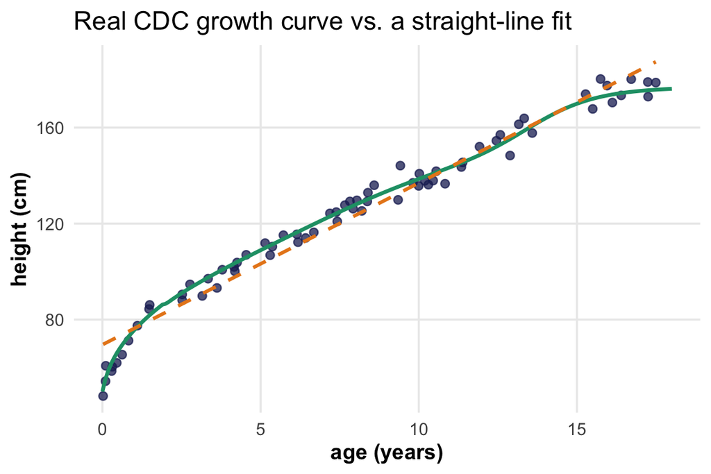

```r
ggplot() +
  geom_point(data = growth_data, aes(age, height), color = NAVY, alpha = 0.75, size = 2) +
  geom_line(data = data.frame(age = age_grid, height = height_curve),
            aes(age, height), color = GREEN, linewidth = 1.1) +
  geom_smooth(data = growth_data, aes(age, height), method = "lm",
              se = FALSE, color = ACCENT, linetype = "dashed", linewidth = 1) +
  labs(x = "age (years)", y = "height (cm)",
       title = "Real CDC growth curve vs. a straight-line fit") +
  theme_deck
```

> **Try it yourself:** the straight-line fit (orange dashed) misses both ends of the real curve (green). Try fitting `height ~ age + I(age^2)` instead — does the fitted curve track the real one more closely? This is exactly the “richer X” fix named on the L slide.

## 4. Figure: the independence reality check

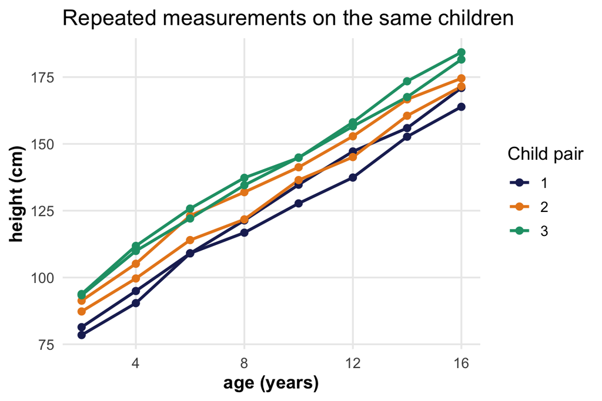

```r
ages_track    <- c(2, 4, 6, 8, 10, 12, 14, 16)
child_offsets <- c(-9, -6, -3, 3, 6, 9)   # 3 pairs, above/below median

independence_data <- lapply(seq_along(child_offsets), function(i) {
  base <- approx(age_anchor, height_median, xout = ages_track)$y + child_offsets[i]
  data.frame(
    child  = paste0("child_", i),
    pair   = ceiling(i / 2),
    age    = ages_track,
    height = base + rnorm(length(ages_track), 0, 1.8)
  )
}) %>% bind_rows()

ggplot(independence_data, aes(age, height, group = child, color = factor(pair))) +
  geom_line(linewidth = 1) +
  geom_point(size = 2) +
  scale_color_manual(values = c(NAVY, ACCENT, GREEN), name = "Child pair") +
  labs(x = "age (years)", y = "height (cm)",
       title = "Repeated measurements on the same children") +
  theme_deck
```

> **Try it yourself:** each “pair” shares a colour. Pick one pair and trace just their two lines. Do they track each other more closely than they track a different-coloured pair? That visual clustering is the independence violation, before any formal test.

## 5. Figure: normality / equal-variance reality check (weight)

```r
n_w        <- 90
ages_w     <- runif(n_w, 0.2, 18)
mean_w     <- approx(weight_age, weight_median, xout = ages_w)$y
weight_sim <- mean_w * exp(rnorm(n_w, 0, 0.18))  # lognormal-ish: skewed, variance grows with mean

weight_data <- data.frame(age = ages_w, weight = weight_sim, mean_w = mean_w)
weight_data$resid <- weight_data$weight - weight_data$mean_w

var_young <- var(weight_data$resid[weight_data$age < 6])
var_old   <- var(weight_data$resid[weight_data$age >= 12])
cat("var(residual), age < 6: ", round(var_young, 1),
    "\nvar(residual), age >= 12:", round(var_old, 1), "\n")
```

```
## var(residual), age < 6:  6.2
## var(residual), age >= 12: 101.9
```

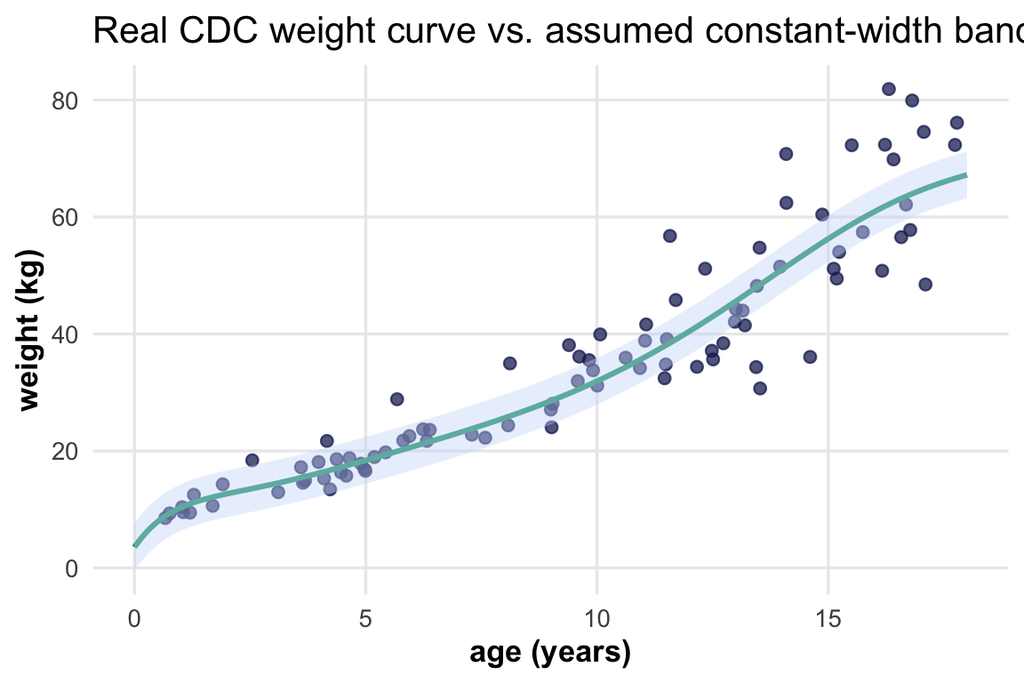

```r
ggplot(weight_data, aes(age, weight)) +
  geom_point(color = NAVY, alpha = 0.75, size = 2) +
  geom_line(data = data.frame(age = age_grid, weight = weight_curve),
            aes(age, weight), color = GREEN, linewidth = 1.1) +
  geom_ribbon(data = data.frame(age = age_grid, weight = weight_curve),
              aes(age, ymin = weight - 4, ymax = weight + 4),
              fill = ICE, alpha = 0.4, inherit.aes = FALSE) +
  labs(x = "age (years)", y = "weight (kg)",
       title = "Real CDC weight curve vs. assumed constant-width band") +
  theme_deck
```

## 6. The eight diagnostic mini-plots: well-behaved vs. violated

Same plot type within each pair. The only thing that should change between “well-behaved” and “violated” is the pattern, not the axes.

```r
theme_mini <- theme_minimal(base_size = 14) +
  theme(axis.text = element_blank(), axis.ticks = element_blank(),
        panel.grid = element_blank(), axis.title = element_text(face = "bold"))
```

### L: Linear (residual vs. fitted)

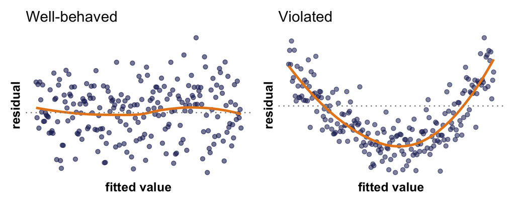

```r
n <- 220
fitted_vals <- seq(0, 10, length.out = n)

L_good <- ggplot(data.frame(fitted = fitted_vals, resid = rnorm(n, 0, 1.3)),
                  aes(fitted, resid)) +
  geom_point(color = NAVY, alpha = 0.6) +
  geom_smooth(method = "loess", se = FALSE, color = ACCENT, linewidth = 1.3) +
  geom_hline(yintercept = 0, linetype = "dotted", color = GREY) +
  labs(x = "fitted value", y = "residual", title = "Well-behaved") + theme_mini

resid_bad_L <- 0.25 * (fitted_vals - 5)^2 - 3 + rnorm(n, 0, 1.4)
L_bad <- ggplot(data.frame(fitted = fitted_vals, resid = resid_bad_L),
                 aes(fitted, resid)) +
  geom_point(color = NAVY, alpha = 0.55) +
  geom_smooth(method = "loess", se = FALSE, color = ACCENT, linewidth = 1.3) +
  geom_hline(yintercept = 0, linetype = "dotted", color = GREY) +
  labs(x = "fitted value", y = "residual", title = "Violated") + theme_mini

library(patchwork)  # install.packages("patchwork") if needed
L_good | L_bad
```

### I: Independent (residual vs. order of observation)

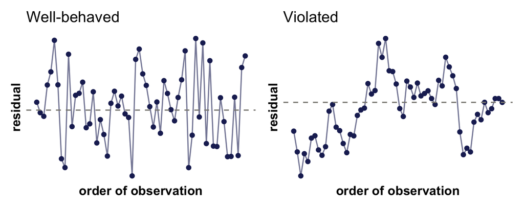

```r
order <- 1:60

I_good <- ggplot(data.frame(order = order, resid = rnorm(60, 0, 1)), aes(order, resid)) +
  geom_line(color = NAVY, alpha = 0.6) + geom_point(color = NAVY) +
  geom_hline(yintercept = 0, linetype = "dashed", color = GREY) +
  labs(x = "order of observation", y = "residual", title = "Well-behaved") + theme_mini

ar <- numeric(60); ar[1] <- rnorm(1)
for (t in 2:60) ar[t] <- 0.85 * ar[t - 1] + rnorm(1, 0, 0.6)
I_bad <- ggplot(data.frame(order = order, resid = ar), aes(order, resid)) +
  geom_line(color = NAVY, alpha = 0.6) + geom_point(color = NAVY) +
  geom_hline(yintercept = 0, linetype = "dashed", color = GREY) +
  labs(x = "order of observation", y = "residual", title = "Violated") + theme_mini

I_good | I_bad
```

### N: Normal (QQ-plot)

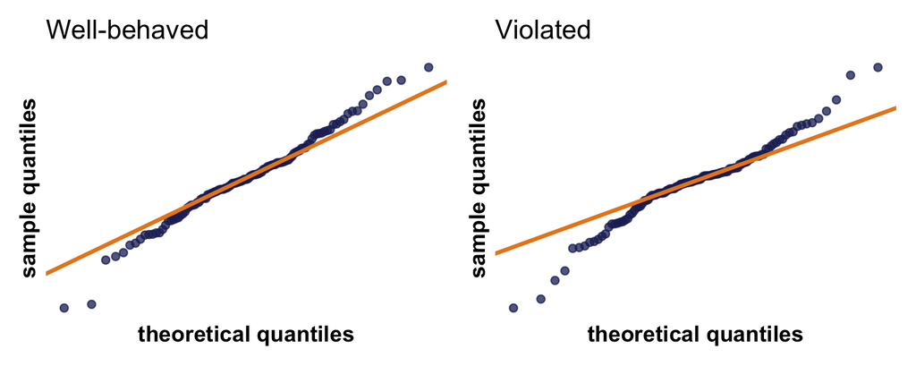

```r
N_good <- ggplot(data.frame(resid = rnorm(120)), aes(sample = resid)) +
  stat_qq(color = NAVY, alpha = 0.75) +
  stat_qq_line(color = ACCENT, linewidth = 1.2) +
  labs(x = "theoretical quantiles", y = "sample quantiles", title = "Well-behaved") + theme_mini

N_bad <- ggplot(data.frame(resid = rt(120, df = 3)), aes(sample = resid)) +
  stat_qq(color = NAVY, alpha = 0.75) +
  stat_qq_line(color = ACCENT, linewidth = 1.2) +
  labs(x = "theoretical quantiles", y = "sample quantiles", title = "Violated") + theme_mini

N_good | N_bad
```

### E: Equal variance (residual vs. fitted)

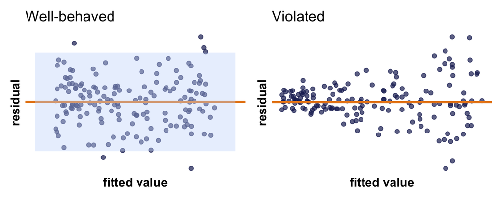

```r
fitted_e <- runif(160, 1, 9)

E_good <- ggplot(data.frame(fitted = fitted_e, resid = rnorm(160, 0, 1)), aes(fitted, resid)) +
  geom_point(color = NAVY, alpha = 0.7) +
  geom_hline(yintercept = 0, color = ACCENT, linewidth = 1.2) +
  geom_ribbon(data = data.frame(fitted = c(0, 10)), aes(x = fitted, ymin = -2, ymax = 2),
              fill = ICE, alpha = 0.4, inherit.aes = FALSE) +
  labs(x = "fitted value", y = "residual", title = "Well-behaved") + theme_mini

E_bad <- ggplot(data.frame(fitted = fitted_e, resid = rnorm(160, 0, 0.3 + 0.35 * fitted_e)),
                 aes(fitted, resid)) +
  geom_point(color = NAVY, alpha = 0.7) +
  geom_hline(yintercept = 0, color = ACCENT, linewidth = 1.2) +
  labs(x = "fitted value", y = "residual", title = "Violated") + theme_mini

E_good | E_bad
```

> **Try it yourself:** in the `L_bad` chunk, change `0.25 * (fitted_vals - 5)^2` to `0.6 * (fitted_vals - 5)^2` (a stronger curvature) and re-run. How much more obvious does the U-shape need to get before you would categorise it as “violated”, rather than borderline ? There is no hard cutoff here.

## 7. Formal tests

Every plot above has a matching formal test. Run them on the real fitted model (`fit`, from Section 2):

```r
resettest(fit, power = 2:3, type = "fitted")   # linearity
```

```
##
##  RESET test
##
## data:  fit
## RESET = 43.726, df1 = 2, df2 = 66, p-value = 8.09e-13
```

```r
dwtest(fit)                                     # independence
```

```
##
##  Durbin-Watson test
##
## data:  fit
## DW = 2.2871, p-value = 0.8907
## alternative hypothesis: true autocorrelation is greater than 0
```

```r
shapiro.test(resid(fit))                        # normality
```

```
##
##  Shapiro-Wilk normality test
##
## data:  resid(fit)
## W = 0.92629, p-value = 0.0005035
```

```r
bptest(fit)                                     # equal variance
```

```
##
##  studentized Breusch-Pagan test
##
## data:  fit
## BP = 5.5044, df = 1, p-value = 0.01897
```

> **Try it yourself:** for each test, find the p-value in the output. A small p-value (conventionally < 0.05) means the test is flagging a likely violation. Do the test results agree with what the plots showed you visually ? They usually do — but they don’t have to, especially with a small sample.

## Wrap-up

If you have run every chunk of code and every “**Try it yourself**” exercise, you have reproduced the entire lecture’s evidence base yourself using the official CDC/NCHS data !